# Visualize DAGs

Zuguang Gu ( z.gu@dkfz.de )

2023-10-16

There are two functions for visualizing DAGs. `dag_graphviz()` uses the **DiagrammeR** package to visualize small DAGs as HTML widgets. `dag_circular_viz()` uses a circular layout for huge DAGs.

## Small DAGs

```r
library(simona)
parents  = c("a", "a", "b", "b", "c", "d")
children = c("b", "c", "c", "d", "e", "f")
dag_small = create_ontology_DAG(parents, children)
```

```r
dag_graphviz(dag_small)
```

[interactive chart not shown]

There are several graphical parameters for controlling nodes in the DAG.

```r
color = sample(colors(), 6)
shape = c("polygon", "box", "oval", "egg", "diamond", "parallelogram")
dag_graphviz(dag_small, color = color, shape = shape)
```

[interactive chart not shown]

The DOT code can be obtained with `dag_as_DOT()`:

```r
dag_as_DOT(dag_small, color = color, shape = shape) |> cat()
```

```
digraph {
  graph [overlap = true]

  node [fontname=Helvetical]
  "a" [color="grey29", style="solid", shape="polygon", fontsize=10, fontcolor="black"];
  "b" [color="grey59", style="solid", shape="box", fontsize=10, fontcolor="black"];
  "c" [color="grey100", style="solid", shape="oval", fontsize=10, fontcolor="black"];
  "d" [color="lightslategrey", style="solid", shape="egg", fontsize=10, fontcolor="black"];
  "e" [color="black", style="solid", shape="diamond", fontsize=10, fontcolor="black"];
  "f" [color="grey71", style="solid", shape="parallelogram", fontsize=10, fontcolor="black"];

  edge [dir="back"]
  "a" -> "b";
  "a" -> "c";
  "b" -> "c";
  "b" -> "d";
  "c" -> "e";
  "d" -> "f";
}
```

You can paste the DOT code to http://magjac.com/graphviz-visual-editor/ to generate the graph.

Following is an example of visualizing all upstream terms of a GO term. Note `dag[, "GO:0010228"]` returns a sub-DAG of all upstream terms of `GO:0010228`.

```r
dag = create_ontology_DAG_from_GO_db()
dag_graphviz(dag[, "GO:0010228"])
```

[interactive chart not shown]

Edge attributes should be set as a named vector where names correspond to all relation types.

```r
dag_graphviz(dag[, "GO:0010228"],
  edge_color = c("is_a" = "purple", "part_of" = "darkgreen"),
  edge_style = c("is_a" = "solid", "part_of" = "dashed"), width = 800, height = 800)
```

[interactive chart not shown]

## Huge DAGs

Visualizing huge DAGs is not an easy job because a term can have more than one parents. Here the `dag_circular_viz()` uses a circular layout to visualize huge DAGs.

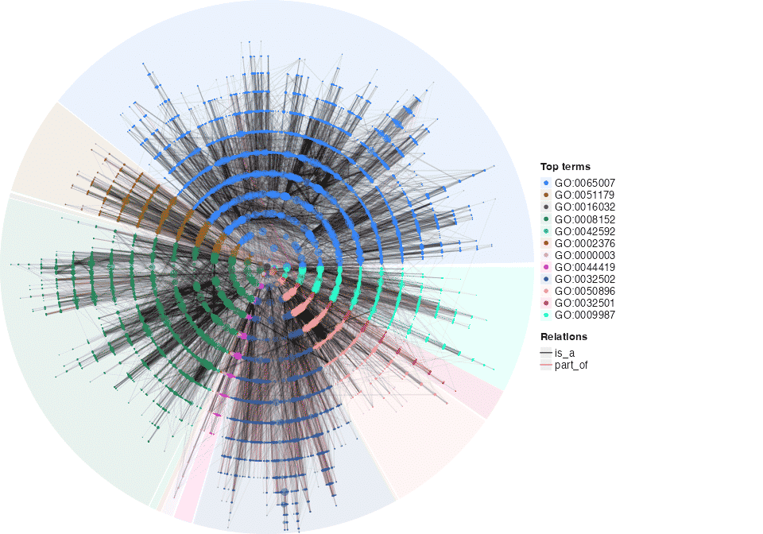

```r
dag_circular_viz(dag)
```

The term IDs are not informative in the plot. If there are additional information of terms stored in the meta data frame of the DAG object, the column name can be set with the `legend_labels_from` argument.

```r
head(mcols(dag))
```

```
##                    id                             name
## GO:0000001 GO:0000001        mitochondrion inheritance
## GO:0000002 GO:0000002 mitochondrial genome maintenance
## GO:0000003 GO:0000003                     reproduction
## GO:0000011 GO:0000011              vacuole inheritance
## GO:0000012 GO:0000012       single strand break repair
## GO:0000017 GO:0000017        alpha-glucoside transport
##                                                                                                                                                                                                                                                                                                   definit…
## GO:0000001                                                                                                           The distribution of mitochondria, including the mitochondrial genome, into daughter cells after mitosis or meiosis, mediated by interactions between mitochondria and the cytoskelet…
## GO:0000002                                                                                                                                                 The maintenance of the structure and integrity of the mitochondrial genome; includes replication and segregation of the mitochondrial chromoso…
## GO:0000003                                                                                                                                                                      The production of new individuals that contain some portion of genetic material inherited from one or more parent organis…
## GO:0000011                                                                                                                                                        The distribution of vacuoles into daughter cells after mitosis or meiosis, mediated by interactions between vacuoles and the cytoskelet…
## GO:0000012                                                                                                                                                      The repair of single strand breaks in DNA. Repair of such breaks is mediated by the same enzyme systems as are used in base excision repa…
## GO:0000017 The directed movement of alpha-glucosides into, out of or within a cell, or between cells, by means of some agent such as a transporter or pore. Alpha-glucosides are glycosides in which the sugar group is a glucose residue, and the anomeric carbon of the bond is in an alpha configurati…
```

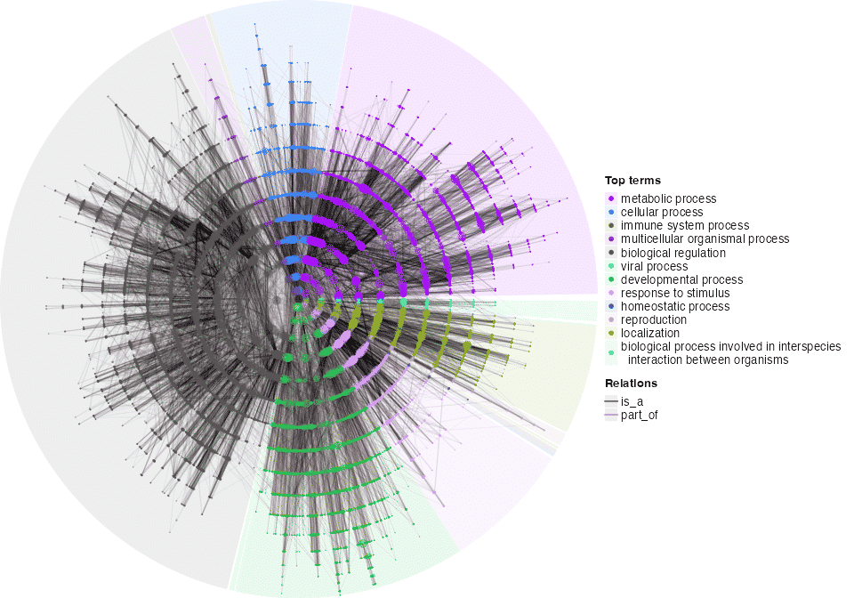

```r
dag_circular_viz(dag, legend_labels_from = "name")
```

`dag_treelize()` can convert a DAG to a tree where a term only has one parent. The circular visualization on the reduced tree is as follows:

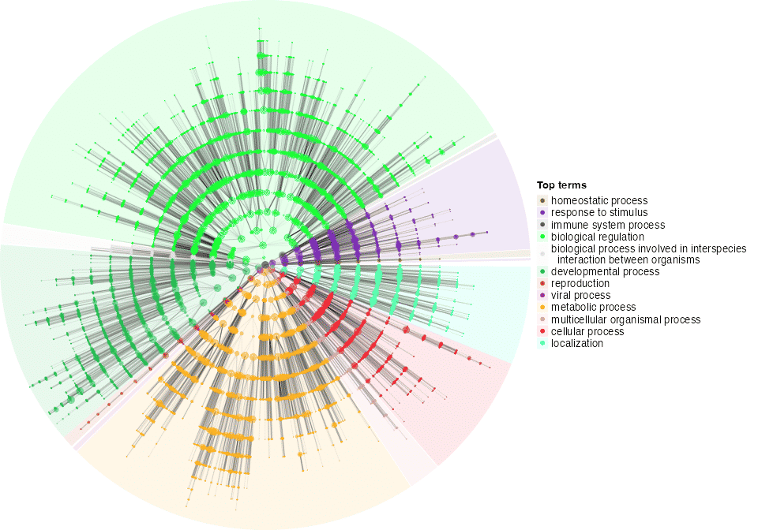

```r
tree = dag_treelize(dag)
dag_circular_viz(tree, legend_labels_from = "name", edge_transparency = 0.95)
```

One useful application is to map GO terms of interest (e.g. significant GO terms from function enrichment analysis) to the DAG. In the following example, `sig_go_ids` contains 249 significant GO terms from an enrichment analysis.

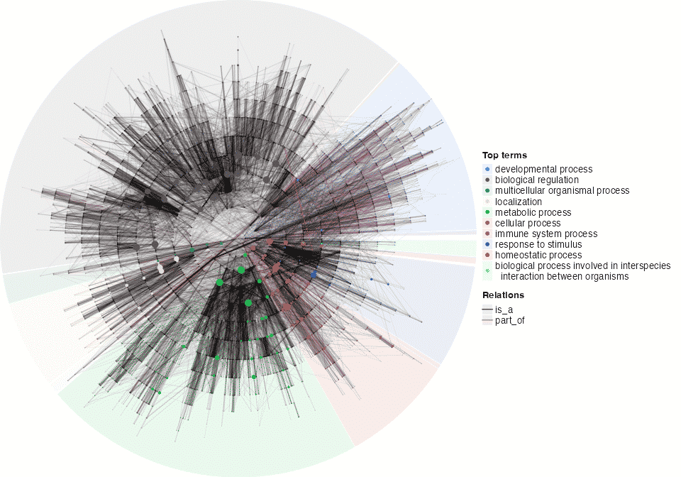

```r
sig_go_ids = readRDS(system.file("extdata", "sig_go_ids.rds", package = "simona"))
dag_circular_viz(dag, highlight = sig_go_ids, legend_labels_from = "name")
```